# Project

Bob Ding, Lynn Fan, Alice Jiang

11/18/2018

# Data Exploration

```r
# input data source
data <- read.csv("./redwine_quality.csv")
```

```r
# convert quality into factor variable
data <- data %>% mutate(quality = as.factor(quality))
```

```r
# overview of the dataset
glimpse(data)
```

```
## Observations: 1,599
## Variables: 12
## $ fixed.acidity        <dbl> 7.4, 7.8, 7.8, 11.2, 7.4, 7.4, 7.9, 7.3, ...
## $ volatile.acidity     <dbl> 0.700, 0.880, 0.760, 0.280, 0.700, 0.660,...
## $ citric.acid          <dbl> 0.00, 0.00, 0.04, 0.56, 0.00, 0.00, 0.06,...
## $ residual.sugar       <dbl> 1.9, 2.6, 2.3, 1.9, 1.9, 1.8, 1.6, 1.2, 2...
## $ chlorides            <dbl> 0.076, 0.098, 0.092, 0.075, 0.076, 0.075,...
## $ free.sulfur.dioxide  <dbl> 11, 25, 15, 17, 11, 13, 15, 15, 9, 17, 15...
## $ total.sulfur.dioxide <dbl> 34, 67, 54, 60, 34, 40, 59, 21, 18, 102, ...
## $ density              <dbl> 0.9978, 0.9968, 0.9970, 0.9980, 0.9978, 0...
## $ pH                   <dbl> 3.51, 3.20, 3.26, 3.16, 3.51, 3.51, 3.30,...
## $ sulphates            <dbl> 0.56, 0.68, 0.65, 0.58, 0.56, 0.56, 0.46,...
## $ alcohol              <dbl> 9.4, 9.8, 9.8, 9.8, 9.4, 9.4, 9.4, 10.0, ...
## $ quality              <fct> 5, 5, 5, 6, 5, 5, 5, 7, 7, 5, 5, 5, 5, 5,...
```

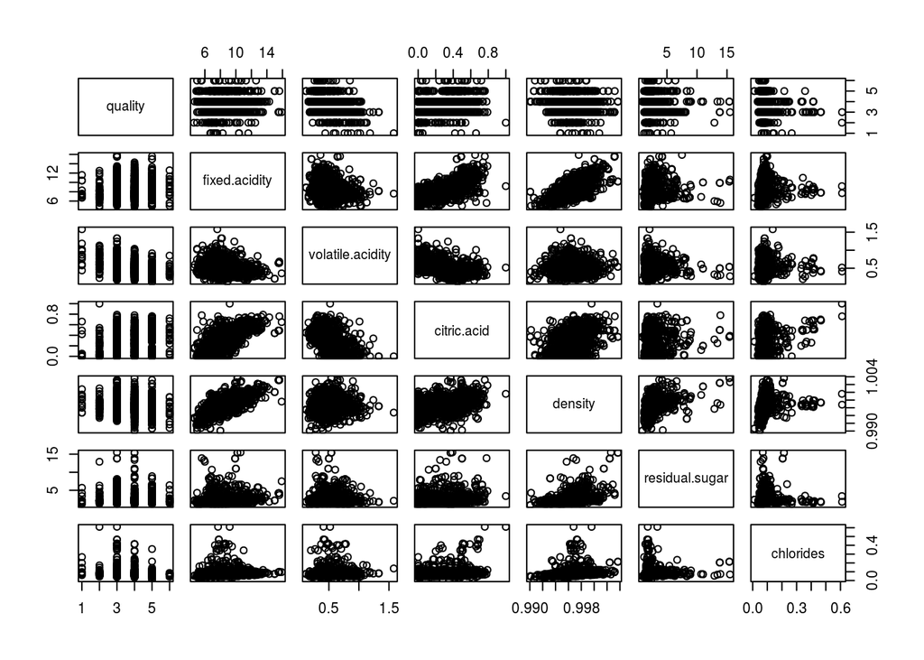

```r
# scatter plot matrix one
pairs(quality ~ fixed.acidity + volatile.acidity + citric.acid + density + residual.sugar + chlorides, data=data)
```

```r
# correlation coefficients for potential multicollinearity
cor(data$fixed.acidity, data$citric.acid)
```

```
## [1] 0.6717034
```

```r
cor(data$fixed.acidity, data$density)
```

```
## [1] 0.6680473
```

```r
cor(data$volatile.acidity, data$citric.acid)
```

```
## [1] -0.5524957
```

```r
cor(data$density, data$residual.sugar)
```

```
## [1] 0.3552834
```

The correlation coefficent for fixed.acidity and citric.acid (0.6717034) and the correlation coefficient for fixed.acidity and density (0.6680473) show moderate to strong linear relationship between the variables. To remove potential multicollinearity impact, we **will not include fixed.acidity** in the model.

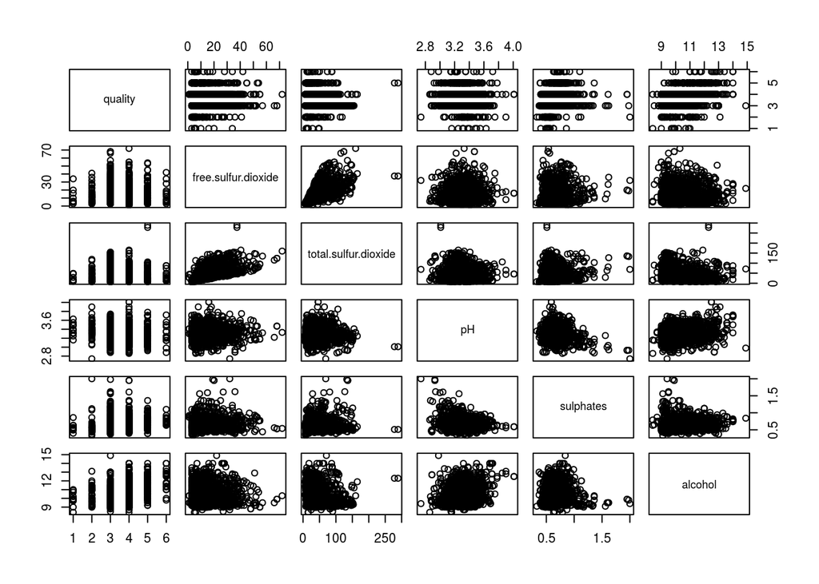

```r
# scatter plot matrix two
pairs(quality ~ free.sulfur.dioxide + total.sulfur.dioxide + pH + sulphates + alcohol, data=data)
```

The scatter plot shows strong positive linear relationship between free.sulfur.dioxide and total.sulfur.dioxide.

```r
# correlation coefficients for potential multicollinearity
cor(data$free.sulfur.dioxide, data$total.sulfur.dioxide)
```

```
## [1] 0.6676665
```

The correlation coefficient of 0.6676665 between free.sulfur.dioxide and total.sulfur.dioxide indicates strong positive linear relationship. We also know from the data description that total.sulfur dioxide includes free.sulfur.dioxide - whose concentration level could impact the smell and taste of the wine, thus impacting quality. So it is sufficient to include only one of these two variables in the model, and we **will include free.sulphur.dioxide**.

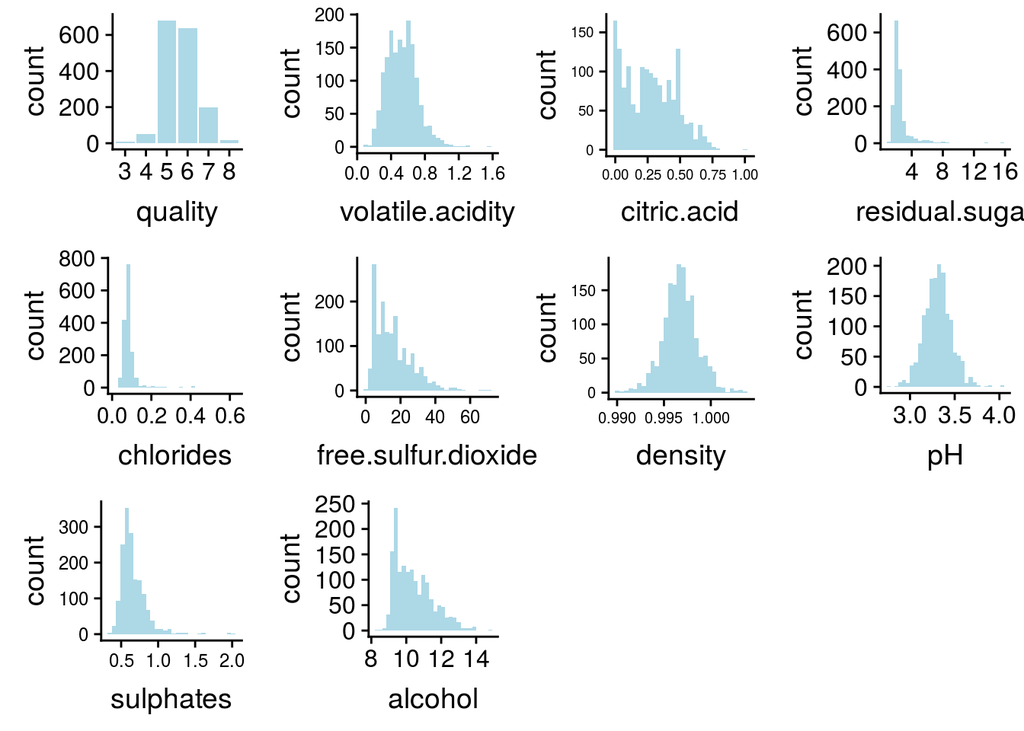

```r
# distribution of each variable
p1  <- ggplot(data = data, aes(x = quality) ) + geom_histogram(stat="count",fill= "lightblue")
p3  <- ggplot(data = data, aes(x = volatile.acidity) ) + theme(axis.text=element_text(size=9)) + geom_histogram(fill= "lightblue")
p4  <- ggplot(data = data, aes(x = citric.acid) ) + theme(axis.text=element_text(size=7)) + geom_histogram(fill= "lightblue")
p5  <- ggplot(data = data, aes(x = residual.sugar) ) + geom_histogram(fill= "lightblue")
p6  <- ggplot(data = data, aes(x = chlorides) ) + theme(axis.text=element_text(size=11)) + geom_histogram(fill= "lightblue")
p7  <- ggplot(data = data, aes(x = free.sulfur.dioxide) ) + theme(axis.text=element_text(size=9)) + geom_histogram(fill= "lightblue")
p9  <- ggplot(data = data, aes(x = density) ) + theme(axis.text=element_text(size=7.5)) + geom_histogram(fill= "lightblue")
p10 <- ggplot(data = data, aes(x = pH) ) + geom_histogram(fill= "lightblue")
p11 <- ggplot(data = data, aes(x = sulphates) ) + theme(axis.text=element_text(size=9)) + geom_histogram(fill= "lightblue")
p12 <- ggplot(data = data, aes(x = alcohol) ) + geom_histogram(fill= "lightblue")

plot_grid(p1,p3,p4,p5,p6,p7,p9,p10,p11,p12,ncol = 4,nrow = 3)
```

```r
# summary statistics of each variable
summary(data)
```

```
##  fixed.acidity   volatile.acidity  citric.acid    residual.sugar
##  Min.   : 4.60   Min.   :0.1200   Min.   :0.000   Min.   : 0.900
##  1st Qu.: 7.10   1st Qu.:0.3900   1st Qu.:0.090   1st Qu.: 1.900
##  Median : 7.90   Median :0.5200   Median :0.260   Median : 2.200
##  Mean   : 8.32   Mean   :0.5278   Mean   :0.271   Mean   : 2.539
##  3rd Qu.: 9.20   3rd Qu.:0.6400   3rd Qu.:0.420   3rd Qu.: 2.600
##  Max.   :15.90   Max.   :1.5800   Max.   :1.000   Max.   :15.500
##    chlorides       free.sulfur.dioxide total.sulfur.dioxide
##  Min.   :0.01200   Min.   : 1.00       Min.   :  6.00
##  1st Qu.:0.07000   1st Qu.: 7.00       1st Qu.: 22.00
##  Median :0.07900   Median :14.00       Median : 38.00
##  Mean   :0.08747   Mean   :15.87       Mean   : 46.47
##  3rd Qu.:0.09000   3rd Qu.:21.00       3rd Qu.: 62.00
##  Max.   :0.61100   Max.   :72.00       Max.   :289.00
##     density             pH          sulphates         alcohol      quality
##  Min.   :0.9901   Min.   :2.740   Min.   :0.3300   Min.   : 8.40   3: 10
##  1st Qu.:0.9956   1st Qu.:3.210   1st Qu.:0.5500   1st Qu.: 9.50   4: 53
##  Median :0.9968   Median :3.310   Median :0.6200   Median :10.20   5:681
##  Mean   :0.9967   Mean   :3.311   Mean   :0.6581   Mean   :10.42   6:638
##  3rd Qu.:0.9978   3rd Qu.:3.400   3rd Qu.:0.7300   3rd Qu.:11.10   7:199
##  Max.   :1.0037   Max.   :4.010   Max.   :2.0000   Max.   :14.90   8: 18
```

From the previous histogram, we can see that quality has a fairly normal distribution. The summary statistic also shows that quality rating of 5 has the most number of observations (it is also the middle rating on the scale of 0-10). So quality rating of 5 is the most appropriate **reference level** for the model.

```r
# makes quality==5 the reference level
data <- data %>% mutate(quality = relevel(quality, ref=5))
```

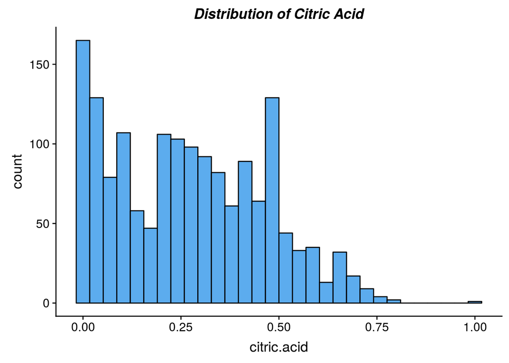

```r
# distribution of citric acid
ggplot(aes(x=citric.acid), data=data) +
  geom_histogram(fill="steelblue2", color="black") +
  ggtitle("Distribution of Citric Acid") +
  theme(plot.title=element_text(color="black", size=14, face="bold.italic", hjust=0.5))
```

```r
# add mean-centered numerical variables besides citric.acid
data <- data %>%
  mutate(volatile.acidityCent = volatile.acidity-mean(volatile.acidity),
         residual.sugarCent = residual.sugar-mean(residual.sugar),
         chloridesCent = chlorides-mean(chlorides),
         free.sulfur.dioxideCent = free.sulfur.dioxide-mean(free.sulfur.dioxide),
         sulphatesCent = sulphates-mean(sulphates),
         densityCent = density-mean(density), pHCent = pH-mean(pH),
         alcoholCent = alcohol-mean(alcohol))
```

# Multiple Regression Analysis

```r
# change quality into a numerical variable
data <- data %>% mutate(quality = as.numeric(quality))
```

```r
# primary model
full.model <- lm(quality ~ volatile.acidityCent + residual.sugarCent + citric.acid + chloridesCent + free.sulfur.dioxideCent + sulphatesCent + densityCent + pHCent + alcoholCent, data=data)
```

```r
# view the primary model
kable(tidy(full.model), format="markdown")
```

| term | estimate | std.error | statistic | p.value |
| --- | --- | --- | --- | --- |
| (Intercept) | 4.2078379 | 0.0770411 | 54.6181017 | 0.0000000 |
| volatile.acidityCent | -0.1346401 | 0.2266206 | -0.5941213 | 0.5525155 |
| residual.sugarCent | -0.0658173 | 0.0256206 | -2.5689180 | 0.0102922 |
| citric.acid | -0.7577667 | 0.2602039 | -2.9122039 | 0.0036390 |
| chloridesCent | 1.4116625 | 0.7778250 | 1.8148844 | 0.0697301 |
| free.sulfur.dioxideCent | 0.0070710 | 0.0031087 | 2.2745911 | 0.0230632 |
| sulphatesCent | -0.5609678 | 0.2159487 | -2.5976900 | 0.0094720 |
| densityCent | 52.5804142 | 25.2708430 | 2.0806751 | 0.0376235 |
| pHCent | 0.0995892 | 0.2550857 | 0.3904146 | 0.6962823 |
| alcoholCent | -0.1430496 | 0.0411678 | -3.4747890 | 0.0005250 |

```r
# check model fit
glance(full.model)
```

```
## # A tibble: 1 x 11
##   r.squared adj.r.squared sigma statistic  p.value    df logLik   AIC   BIC
## *     <dbl>         <dbl> <dbl>     <dbl>    <dbl> <int>  <dbl> <dbl> <dbl>
## 1    0.0559        0.0506  1.24      10.5 7.54e-16    10 -2610. 5241. 5301.
## # ... with 2 more variables: deviance <dbl>, df.residual <int>
```

This is the primary model we constructed based on the exploratory analysis. We can see that volatile.acidityCent, chloridesCent, and pHCent have p-values greater than 0.05. The model’s $R^2$ value 0.0559 is noticeably higher than the Adjusted $R^2$ of 0.0506, penalizing for unnecessary variables in the model.

We will then use model selection to build a better model, first including only the main effects.

## Model Selections

```r
# backward selection process
backward <- ols_step_backward_aic(full.model, details=TRUE)
```

```
## Backward Elimination Method
## ---------------------------
##
## Candidate Terms:
##
## 1 . volatile.acidityCent
## 2 . residual.sugarCent
## 3 . citric.acid
## 4 . chloridesCent
## 5 . free.sulfur.dioxideCent
## 6 . sulphatesCent
## 7 . densityCent
## 8 . pHCent
## 9 . alcoholCent
##
##  Step 0: AIC = 5241.352
##  quality ~ volatile.acidityCent + residual.sugarCent + citric.acid + chloridesCent + free.sulfur.dioxideCent + sulphatesCent + densityCent + pHCent + alcoholCent
##
## -------------------------------------------------------------------------------------
## Variable                   DF      AIC       Sum Sq      RSS       R-Sq     Adj. R-Sq
## -------------------------------------------------------------------------------------
## pHCent                     1     5239.505     0.235    2449.128    0.056        0.051
## volatile.acidityCent       1     5239.707     0.544    2449.437    0.056        0.051
## chloridesCent              1     5242.663     5.076    2453.970    0.054        0.049
## densityCent                1     5243.702     6.672    2455.565    0.053        0.049
## free.sulfur.dioxideCent    1     5244.550     7.974    2456.867    0.053        0.048
## residual.sugarCent         1     5245.979    10.171    2459.064    0.052        0.047
## sulphatesCent              1     5246.128    10.400    2459.293    0.052        0.047
## citric.acid                1     5247.863    13.070    2461.964    0.051        0.046
## alcoholCent                1     5251.456    18.608    2467.502    0.049        0.044
## -------------------------------------------------------------------------------------
##
##
## - pHCent
##
##
##   Step 1 : AIC = 5239.505
##  quality ~ volatile.acidityCent + residual.sugarCent + citric.acid + chloridesCent + free.sulfur.dioxideCent + sulphatesCent + densityCent + alcoholCent
##
## -------------------------------------------------------------------------------------
```

[output cut: 61 more lines]

```
## ----------------------------------------------------------------------
##
##                                         Parameter Estimates
## ----------------------------------------------------------------------------------------------------
##                   model      Beta    Std. Error    Std. Beta      t        Sig      lower     upper
## ----------------------------------------------------------------------------------------------------
##             (Intercept)     4.198         0.060                 69.597    0.000     4.079     4.316
##      residual.sugarCent    -0.066         0.026       -0.073    -2.576    0.010    -0.116    -0.016
##             citric.acid    -0.720         0.191       -0.110    -3.773    0.000    -1.095    -0.346
##           chloridesCent     1.267         0.750        0.047     1.691    0.091    -0.203     2.738
## free.sulfur.dioxideCent     0.007         0.003        0.059     2.334    0.020     0.001     0.013
##           sulphatesCent    -0.536         0.211       -0.071    -2.542    0.011    -0.950    -0.123
##             densityCent    49.122        24.490        0.073     2.006    0.045     1.087    97.158
##             alcoholCent    -0.141         0.040       -0.118    -3.539    0.000    -0.219    -0.063
## ----------------------------------------------------------------------------------------------------
```

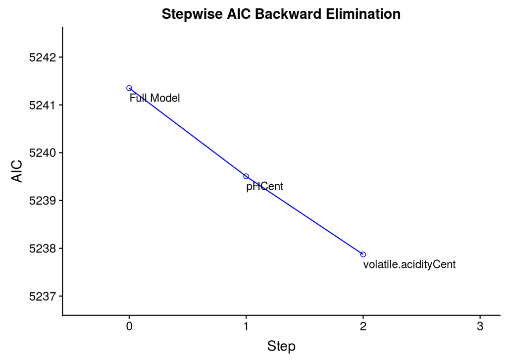

```r
# view stepwise AIC backward elimination
plot(backward)
```

The backward selection removes pHCent and volatile.acidityCent from the model.

```r
# forward selection process
forward <- ols_step_forward_aic(full.model, details=TRUE)
```

```
## Forward Selection Method
## ------------------------
##
## Candidate Terms:
##
## 1 . volatile.acidityCent
## 2 . residual.sugarCent
## 3 . citric.acid
## 4 . chloridesCent
## 5 . free.sulfur.dioxideCent
## 6 . sulphatesCent
## 7 . densityCent
## 8 . pHCent
## 9 . alcoholCent
##
##  Step 0: AIC = 5315.392
##  quality ~ 1
##
## -------------------------------------------------------------------------------------
## Variable                   DF      AIC       Sum Sq      RSS       R-Sq     Adj. R-Sq
## -------------------------------------------------------------------------------------
## alcoholCent                 1    5258.390    93.971    2500.019    0.036        0.036
## citric.acid                 1    5292.863    39.488    2554.502    0.015        0.015
## volatile.acidityCent        1    5302.658    23.791    2570.199    0.009        0.009
## sulphatesCent               1    5305.527    19.176    2574.814    0.007        0.007
## densityCent                 1    5311.101    10.185    2583.805    0.004        0.003
## free.sulfur.dioxideCent     1    5312.446     8.011    2585.979    0.003        0.002
## residual.sugarCent          1    5312.626     7.720    2586.270    0.003        0.002
## chloridesCent               1    5315.451     3.146    2590.844    0.001        0.001
## pHCent                      1    5315.916     2.392    2591.598    0.001        0.000
## -------------------------------------------------------------------------------------
##
##
## - alcoholCent
##
##
##  Step 1 : AIC = 5258.39
##  quality ~ alcoholCent
##
## -------------------------------------------------------------------------------------
```

[output cut: 141 more lines]

```
## ----------------------------------------------------------------------
##
##                                         Parameter Estimates
## ----------------------------------------------------------------------------------------------------
##                   model      Beta    Std. Error    Std. Beta      t        Sig      lower     upper
## ----------------------------------------------------------------------------------------------------
##             (Intercept)     4.198         0.060                 69.597    0.000     4.079     4.316
##             alcoholCent    -0.141         0.040       -0.118    -3.539    0.000    -0.219    -0.063
##             citric.acid    -0.720         0.191       -0.110    -3.773    0.000    -1.095    -0.346
##           sulphatesCent    -0.536         0.211       -0.071    -2.542    0.011    -0.950    -0.123
## free.sulfur.dioxideCent     0.007         0.003        0.059     2.334    0.020     0.001     0.013
##      residual.sugarCent    -0.066         0.026       -0.073    -2.576    0.010    -0.116    -0.016
##             densityCent    49.122        24.490        0.073     2.006    0.045     1.087    97.158
##           chloridesCent     1.267         0.750        0.047     1.691    0.091    -0.203     2.738
## ----------------------------------------------------------------------------------------------------
```

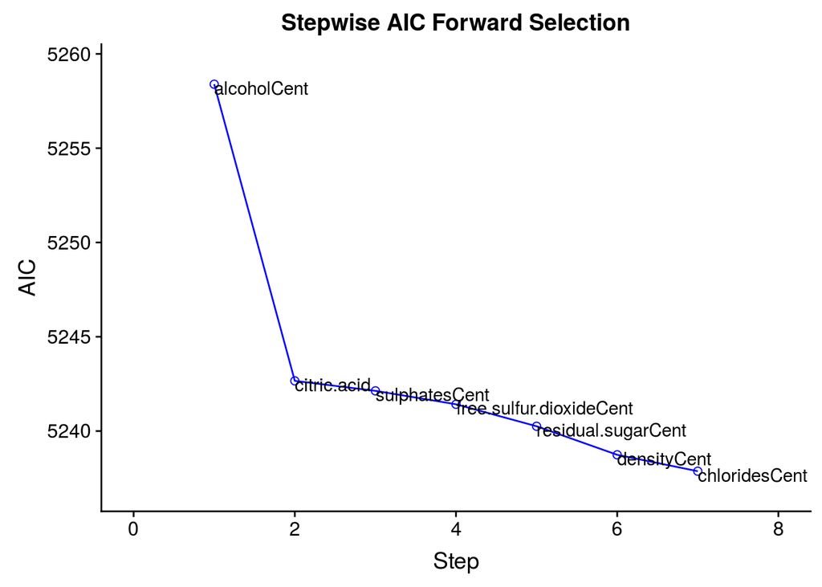

```r
# view stepwise AIC forward selection
plot(forward)
```

We can see the foward selection process includes the same explanatory variables as the model from the backward selection - both models do not include volatile.acidityCent and pHCent from the full.model.

```r
# stepwise selection process
stepwise <- ols_step_both_aic(full.model, details=TRUE)
```

```
## Stepwise Selection Method
## -------------------------
##
## Candidate Terms:
##
## 1 . volatile.acidityCent
## 2 . residual.sugarCent
## 3 . citric.acid
## 4 . chloridesCent
## 5 . free.sulfur.dioxideCent
## 6 . sulphatesCent
## 7 . densityCent
## 8 . pHCent
## 9 . alcoholCent
##
##  Step 0: AIC = 5315.392
##  quality ~ 1
##
##
##                                   Enter New Variables
## -------------------------------------------------------------------------------------
## Variable                   DF      AIC       Sum Sq      RSS       R-Sq     Adj. R-Sq
## -------------------------------------------------------------------------------------
## alcoholCent                 1    5258.390    93.971    2500.019    0.036        0.036
## citric.acid                 1    5292.863    39.488    2554.502    0.015        0.015
## volatile.acidityCent        1    5302.658    23.791    2570.199    0.009        0.009
## sulphatesCent               1    5305.527    19.176    2574.814    0.007        0.007
## densityCent                 1    5311.101    10.185    2583.805    0.004        0.003
## free.sulfur.dioxideCent     1    5312.446     8.011    2585.979    0.003        0.002
## residual.sugarCent          1    5312.626     7.720    2586.270    0.003        0.002
## chloridesCent               1    5315.451     3.146    2590.844    0.001        0.001
## pHCent                      1    5315.916     2.392    2591.598    0.001        0.000
## -------------------------------------------------------------------------------------
##
## - alcoholCent added
##
##
##  Step 1 : AIC = 5258.39
##  quality ~ alcoholCent
##
```

[output cut: 201 more lines]

```
## ----------------------------------------------------------------------
##
##                                         Parameter Estimates
## ----------------------------------------------------------------------------------------------------
##                   model      Beta    Std. Error    Std. Beta      t        Sig      lower     upper
## ----------------------------------------------------------------------------------------------------
##             (Intercept)     4.198         0.060                 69.597    0.000     4.079     4.316
##             alcoholCent    -0.141         0.040       -0.118    -3.539    0.000    -0.219    -0.063
##             citric.acid    -0.720         0.191       -0.110    -3.773    0.000    -1.095    -0.346
##           sulphatesCent    -0.536         0.211       -0.071    -2.542    0.011    -0.950    -0.123
## free.sulfur.dioxideCent     0.007         0.003        0.059     2.334    0.020     0.001     0.013
##      residual.sugarCent    -0.066         0.026       -0.073    -2.576    0.010    -0.116    -0.016
##             densityCent    49.122        24.490        0.073     2.006    0.045     1.087    97.158
##           chloridesCent     1.267         0.750        0.047     1.691    0.091    -0.203     2.738
## ----------------------------------------------------------------------------------------------------
```

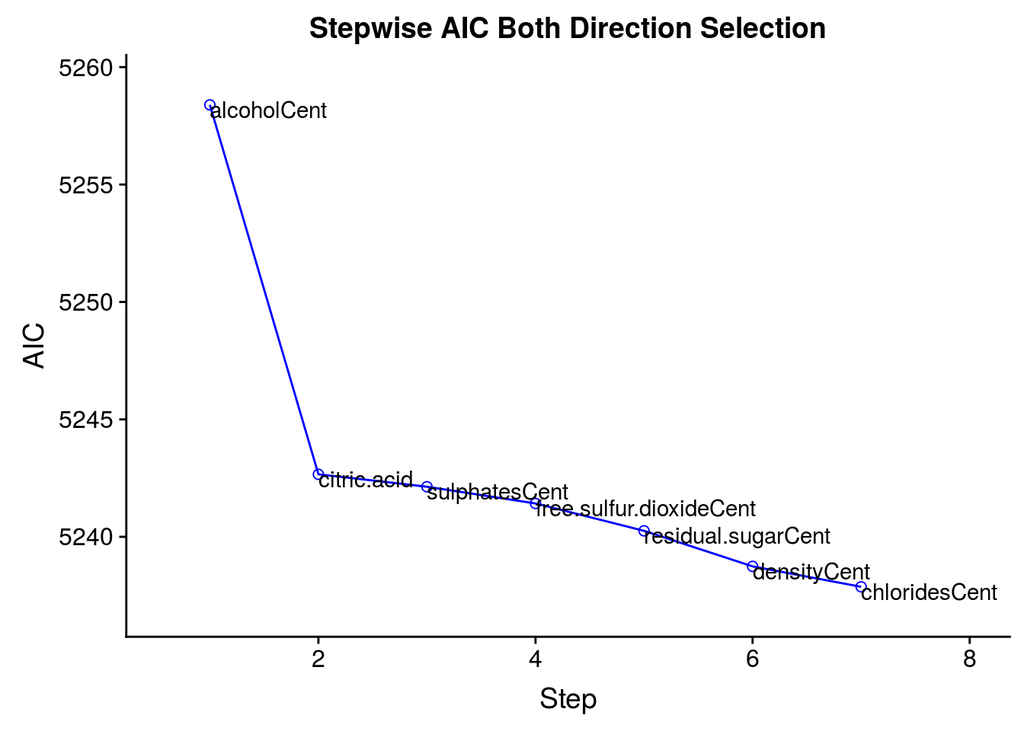

```r
# view stepwise AIC two-direction selection
plot(stepwise)
```

The plot for stepwise selection looks the same as the plot for forward selection. Therefore, for all three model selections, we obtain the same result of including all variables from the full.model, except for volatile.acidityCent and pHCent.

```r
# new model from model selection
selected <- lm(quality ~ residual.sugarCent + citric.acid + chloridesCent + free.sulfur.dioxideCent + sulphatesCent + densityCent + alcoholCent, data=data)
```

```r
# view coefficients of the new model
kable(tidy(selected), format="markdown")
```

| term | estimate | std.error | statistic | p.value |
| --- | --- | --- | --- | --- |
| (Intercept) | 4.1976490 | 0.0603138 | 69.596873 | 0.0000000 |
| residual.sugarCent | -0.0659177 | 0.0255864 | -2.576285 | 0.0100763 |
| citric.acid | -0.7201660 | 0.1908611 | -3.773246 | 0.0001670 |
| chloridesCent | 1.2672316 | 0.7495997 | 1.690544 | 0.0911197 |
| free.sulfur.dioxideCent | 0.0072279 | 0.0030962 | 2.334443 | 0.0196964 |
| sulphatesCent | -0.5363162 | 0.2109507 | -2.542377 | 0.0111042 |
| densityCent | 49.1224937 | 24.4896196 | 2.005850 | 0.0450413 |
| alcoholCent | -0.1409656 | 0.0398305 | -3.539138 | 0.0004130 |

We can see that chloridesCent has a p-value much greater than 0.05, so we consider chloridesCent to be a statistically insignificant predictor and remove it from the model.

```r
# model after removing chloridesCent
model <- lm(quality ~ residual.sugarCent + citric.acid + free.sulfur.dioxideCent + sulphatesCent + densityCent + alcoholCent, data=data)
```

```r
# view the model
kable(tidy(model), format="markdown")
```

| term | estimate | std.error | statistic | p.value |
| --- | --- | --- | --- | --- |
| (Intercept) | 4.1855088 | 0.0599196 | 69.852023 | 0.0000000 |
| residual.sugarCent | -0.0619426 | 0.0254929 | -2.429795 | 0.0152173 |
| citric.acid | -0.6753641 | 0.1891225 | -3.571040 | 0.0003661 |
| free.sulfur.dioxideCent | 0.0069545 | 0.0030938 | 2.247889 | 0.0247197 |
| sulphatesCent | -0.4044692 | 0.1961185 | -2.062372 | 0.0393342 |
| densityCent | 45.7026073 | 24.4201616 | 1.871511 | 0.0614575 |
| alcoholCent | -0.1596179 | 0.0382941 | -4.168207 | 0.0000324 |

```r
# multicollinearity check
kable(tidy(vif(model)))
```

| names | x |
| --- | --- |
| residual.sugarCent | 1.339256 |
| citric.acid | 1.407016 |
| free.sulfur.dioxideCent | 1.085642 |
| sulphatesCent | 1.145623 |
| densityCent | 2.202034 |
| alcoholCent | 1.726386 |

A quick examination of the model using the VIF() function shows no noticeable detection of multicollinearity effects - all vif values are quite small, ranging around 1 to 2.

We will then examine possible interaction effects between the selected variables.

## Nested F Tests on Interactions

```r
# interaction effects with residual.sugarCent
model_rs <- lm(quality ~ residual.sugarCent + citric.acid + free.sulfur.dioxideCent + sulphatesCent + densityCent + alcoholCent + residual.sugarCent*citric.acid + residual.sugarCent*free.sulfur.dioxideCent + residual.sugarCent*sulphatesCent + residual.sugarCent*densityCent + residual.sugarCent*alcoholCent, data=data)
```

```r
# Nested F Test for interaction with residual.sugarCent
ano1 <- anova(model_rs, model)
kable(tidy(ano1))
```

| res.df | rss | df | sumsq | statistic | p.value |
| --- | --- | --- | --- | --- | --- |
| 1587 | 2447.619 | NA | NA | NA | NA |
| 1592 | 2454.089 | -5 | -6.470218 | 0.8390388 | 0.5218901 |

p-value is much higher than 0.05, so there is no significant interactions with residual.sugarCent that impact wine quality.

```r
# Nested F Test for interaction effect between alcohol and density
model_da <- lm(quality ~ residual.sugarCent + citric.acid + free.sulfur.dioxideCent + sulphatesCent + densityCent + alcoholCent + alcoholCent*densityCent, data=data)
ano2 <- anova(model_da, model)
kable(tidy(ano2))
```

| res.df | rss | df | sumsq | statistic | p.value |
| --- | --- | --- | --- | --- | --- |
| 1591 | 2452.915 | NA | NA | NA | NA |
| 1592 | 2454.089 | -1 | -1.173729 | 0.7612995 | 0.3830538 |

p-value is much larger than 0.05, so there is no significant interaction effect between alcoholCent an densityCent.

```r
# Nested F Test for all other two-way interactions
model1 <- lm(quality ~ residual.sugarCent + citric.acid + free.sulfur.dioxideCent + sulphatesCent + densityCent + alcoholCent + citric.acid*free.sulfur.dioxideCent + citric.acid*sulphatesCent + citric.acid*densityCent + citric.acid*alcoholCent + free.sulfur.dioxideCent*sulphatesCent + free.sulfur.dioxideCent*densityCent + free.sulfur.dioxideCent*alcoholCent + sulphatesCent*densityCent + sulphatesCent*alcoholCent, data=data)
ano3 <- anova(model1, model)
kable(tidy(ano3))
```

| res.df | rss | df | sumsq | statistic | p.value |
| --- | --- | --- | --- | --- | --- |
| 1583 | 2355.529 | NA | NA | NA | NA |
| 1592 | 2454.089 | -9 | -98.55976 | 7.359521 | 0 |

The p-value is extremely small, so there is at least one significant interaction effects. We will then investigate which specific interactions are significant using backward model selection.

```r
# backward selection
backward_new <- ols_step_backward_aic(model1, details=TRUE)
```

```
## Backward Elimination Method
## ---------------------------
##
## Candidate Terms:
##
## 1 . residual.sugarCent
## 2 . citric.acid
## 3 . free.sulfur.dioxideCent
## 4 . sulphatesCent
## 5 . densityCent
## 6 . alcoholCent
## 7 . citric.acid:free.sulfur.dioxideCent
## 8 . citric.acid:sulphatesCent
## 9 . citric.acid:densityCent
## 10 . citric.acid:alcoholCent
## 11 . free.sulfur.dioxideCent:sulphatesCent
## 12 . free.sulfur.dioxideCent:densityCent
## 13 . free.sulfur.dioxideCent:alcoholCent
## 14 . sulphatesCent:densityCent
## 15 . sulphatesCent:alcoholCent
##
##  Step 0: AIC = 5191.197
##  quality ~ residual.sugarCent + citric.acid + free.sulfur.dioxideCent + sulphatesCent + densityCent + alcoholCent + citric.acid:free.sulfur.dioxideCent + citric.acid:sulphatesCent + citric.acid:densityCent + citric.acid:alcoholCent + free.sulfur.dioxideCent:sulphatesCent + free.sulfur.dioxideCent…
##
## ---------------------------------------------------------------------------------------------------
## Variable                                 DF      AIC       Sum Sq      RSS       R-Sq     Adj. R-Sq
## ---------------------------------------------------------------------------------------------------
## free.sulfur.dioxideCent:densityCent      1     5189.204     0.010    2355.539    0.092        0.084
## sulphatesCent                            1     5189.249     0.076    2355.605    0.092        0.084
## citric.acid:densityCent                  1     5189.348     0.222    2355.751    0.092        0.084
## sulphatesCent:densityCent                1     5189.368     0.251    2355.780    0.092        0.084
## free.sulfur.dioxideCent:sulphatesCent    1     5189.401     0.301    2355.830    0.092        0.084
## citric.acid:alcoholCent                  1     5189.595     0.586    2356.115    0.092        0.084
## densityCent                              1     5190.154     1.409    2356.939    0.091        0.083
## alcoholCent                              1     5191.894     3.976    2359.505    0.090        0.082
## residual.sugarCent                       1     5192.655     5.099    2360.628    0.090        0.082
## citric.acid:sulphatesCent                1     5195.135     8.763    2364.292    0.089        0.080
## citric.acid:free.sulfur.dioxideCent      1     5195.927     9.935    2365.464    0.088        0.080
## free.sulfur.dioxideCent:alcoholCent      1     5196.262    10.431    2365.960    0.088        0.080
## citric.acid                              1     5200.598    16.855    2372.384    0.085        0.077
```

[output cut: 177 more lines]

```
##                                                Parameter Estimates
## -----------------------------------------------------------------------------------------------------------------
##                               model      Beta    Std. Error    Std. Beta      t        Sig      lower      upper
## -----------------------------------------------------------------------------------------------------------------
##                         (Intercept)     4.230         0.058                 72.489    0.000     4.115      4.344
##                  residual.sugarCent    -0.050         0.026       -0.056    -1.967    0.049    -0.100      0.000
##                         citric.acid    -0.656         0.186       -0.100    -3.522    0.000    -1.022     -0.291
##             free.sulfur.dioxideCent     0.020         0.005        0.165     3.905    0.000     0.010      0.030
##                         densityCent    55.633        24.090        0.082     2.309    0.021     8.381    102.884
##                         alcoholCent    -0.139         0.038       -0.116    -3.655    0.000    -0.214     -0.064
## citric.acid:free.sulfur.dioxideCent    -0.043         0.016       -0.118    -2.748    0.006    -0.074     -0.012
##           citric.acid:sulphatesCent    -2.357         0.490       -0.130    -4.811    0.000    -3.318     -1.396
## free.sulfur.dioxideCent:alcoholCent     0.010         0.003        0.087     3.494    0.000     0.004      0.016
##           alcoholCent:sulphatesCent    -1.339         0.193       -0.180    -6.928    0.000    -1.718     -0.960
## -----------------------------------------------------------------------------------------------------------------
```

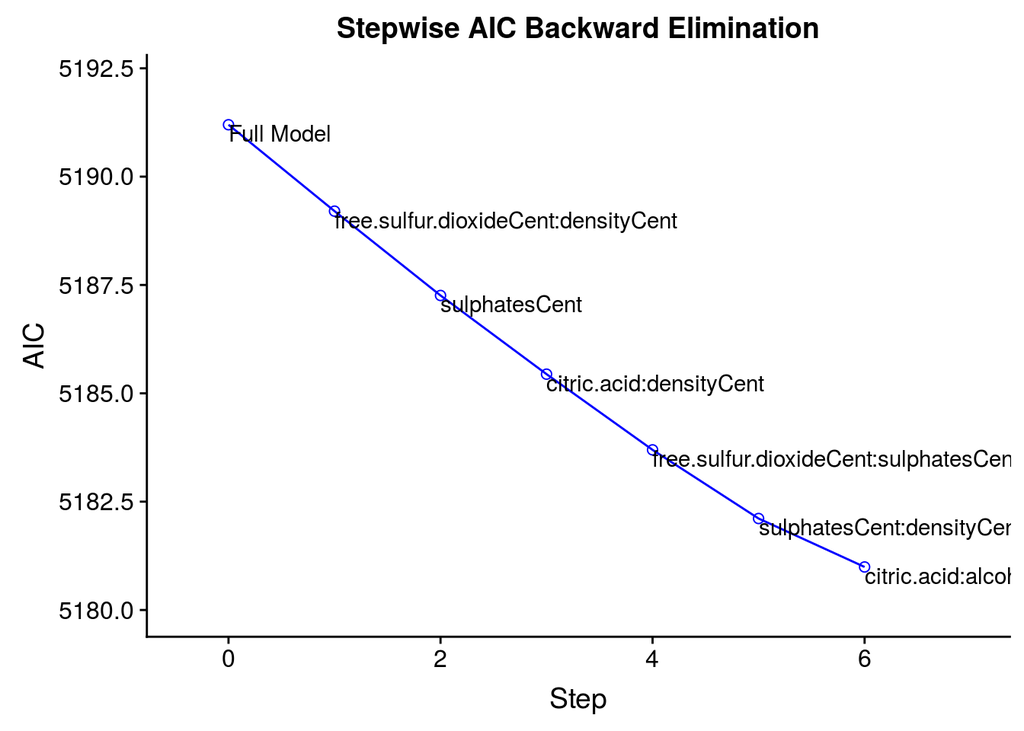

```r
# view the stepwise AIC backward elimination
plot(backward_new)
```

Backward model selection removes 5 interaction effects and sulphatesCent. However, since the model still includes some interaction effects with sulphatesCent, we will keep this main effect in the model.

```r
# new model after backward selection
model2 <- lm(quality ~ residual.sugarCent + citric.acid + free.sulfur.dioxideCent + sulphatesCent + densityCent + alcoholCent + citric.acid*free.sulfur.dioxideCent + citric.acid*sulphatesCent + free.sulfur.dioxideCent*alcoholCent + sulphatesCent*alcoholCent, data=data)
kable(tidy(model2), format="markdown")
```

| term | estimate | std.error | statistic | p.value |
| --- | --- | --- | --- | --- |
| (Intercept) | 4.2245320 | 0.0592509 | 71.2990038 | 0.0000000 |
| residual.sugarCent | -0.0512202 | 0.0256054 | -2.0003694 | 0.0456304 |
| citric.acid | -0.6497755 | 0.1867955 | -3.4785390 | 0.0005178 |
| free.sulfur.dioxideCent | 0.0204311 | 0.0051881 | 3.9380530 | 0.0000857 |
| sulphatesCent | -0.1836422 | 0.3561499 | -0.5156318 | 0.6061833 |
| densityCent | 57.4648324 | 24.3560389 | 2.3593669 | 0.0184266 |
| alcoholCent | -0.1355440 | 0.0386503 | -3.5069347 | 0.0004659 |
| citric.acid:free.sulfur.dioxideCent | -0.0437867 | 0.0157370 | -2.7824077 | 0.0054596 |
| citric.acid:sulphatesCent | -1.9995045 | 0.8489262 | -2.3553337 | 0.0186271 |
| free.sulfur.dioxideCent:alcoholCent | 0.0103289 | 0.0029290 | 3.5264524 | 0.0004331 |
| sulphatesCent:alcoholCent | -1.3476692 | 0.1940602 | -6.9445928 | 0.0000000 |

We can see that p-value of all the coefficients are less than the threshold of 0.05, except for sulphatesCent. Therefore, these main and interaction effects are significant predictors of wine quality (besides sulphatesCent). So we will make model2 our final model.

```r
# make model2 the final multiple regression model
final.model <- lm(quality ~ residual.sugarCent + citric.acid + free.sulfur.dioxideCent + sulphatesCent + densityCent + alcoholCent + citric.acid*free.sulfur.dioxideCent + citric.acid*sulphatesCent + free.sulfur.dioxideCent*alcoholCent + sulphatesCent*alcoholCent, data=data)
```

Our final multiple reression model:  
$quality = 4.2245 - 0.0512*residual.sugarCent - 0.6498*citric.acid + 0.0204*free.sulfur.dioxideCent - 0.1836*sulphatesCent + 57.4648*densityCent - 0.1355*alcoholCent - 0.0438*citric.acid*free.sulfur.dioxideCent - 1.9995*citric.acid*sulphatesCent + 0.0103*free.sulfur.dioxideCent*alcoholCent - 1.3477*sulphatesCent*alcoholCent$

## Assumptions

### Residual Plots

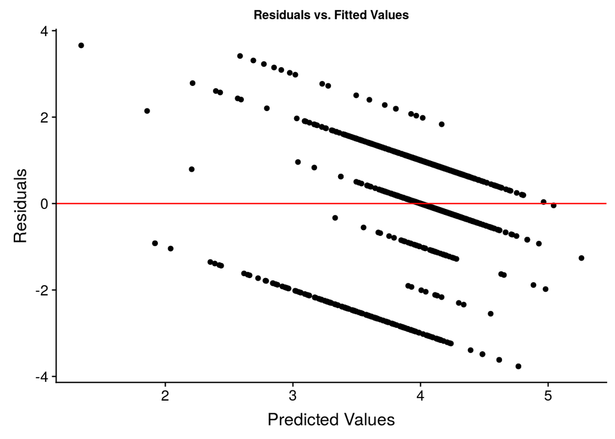

```r
data <- data %>% mutate(predicted = predict.lm(final.model))
data <- data %>% mutate(resid=resid(final.model))
ggplot(data, aes(predicted, resid)) + geom_point() +
  geom_hline(yintercept=0, color="red") + labs(x="Predicted Values", y="Residuals",
  title="Residuals vs. Fitted Values") + theme(plot.title=element_text(hjust=0.5,
  size=10))
```

### Normaltiy

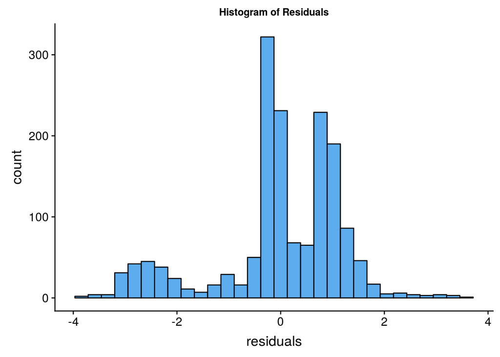

```r
# distribution of residuals
ggplot(data, aes(resid)) + geom_histogram(color="black",
  fill="steelblue2") + labs(x="residuals", y="count", title="Histogram of Residuals") +
  theme(plot.title=element_text(hjust=0.5, size=10))
```

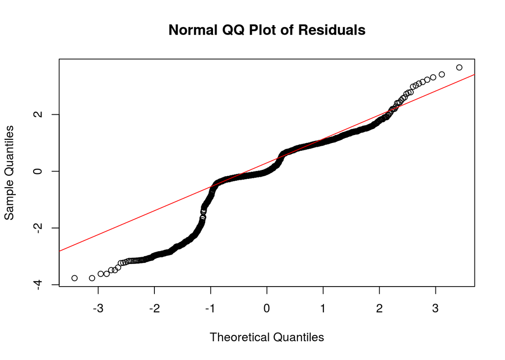

```r
# QQ Plot
qqnorm(data$resid, main="Normal QQ Plot of Residuals")
qqline(data$resid, col="red")
```

### Influence Points

```r
data <- data %>% mutate(leverage = hatvalues(final.model), cooks =
  cooks.distance(final.model), stand.resid = rstandard(final.model), obs.num =
  row_number())
```

```r
# calculate leverage threshold
t <- 2*10/1599
```

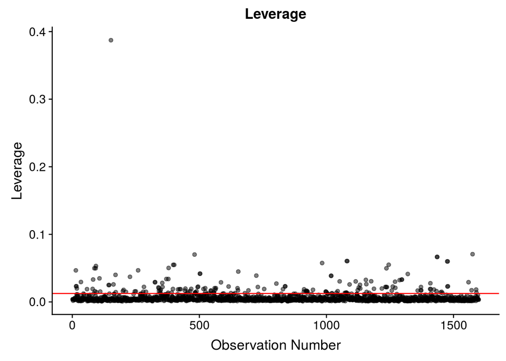

```r
# leverage
ggplot(data=data, aes(x=obs.num, y=leverage)) +
  geom_point(alpha=0.5) +
  geom_hline(yintercept=t, color="red") +
  labs(x="Observation Number", y="Leverage", title="Leverage")
```

We can see that there is one point with a significantly high leverage around 0.4, comparing with other observations. This could be an outlier and might be an influence point.

```r
#data %>% filter(leverage > 0.3) %>%
  #select(citric.acid, residual.sugarCent, free.sulfur.dioxideCent, sulphatesCent, densityCent, alcoholCent)
```

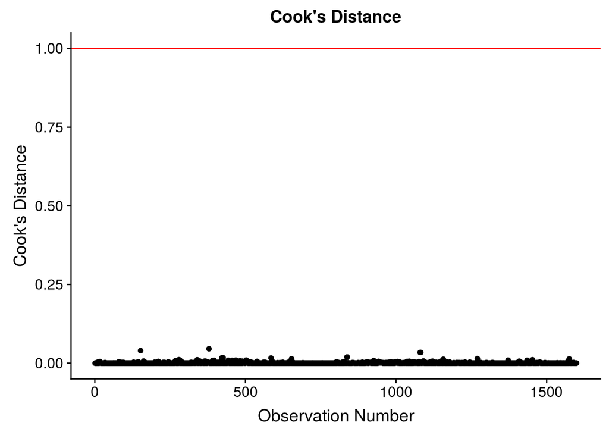

```r
# Cook’s Distance
ggplot(data=data, aes(x=obs.num, y=cooks)) +
  geom_point() +
  geom_hline(yintercept=1, color="red")+
  labs(x="Observation Number", y="Cook's Distance", title="Cook's Distance")
```

The Cook’s Distance for all observations are far below the threshold of 1.

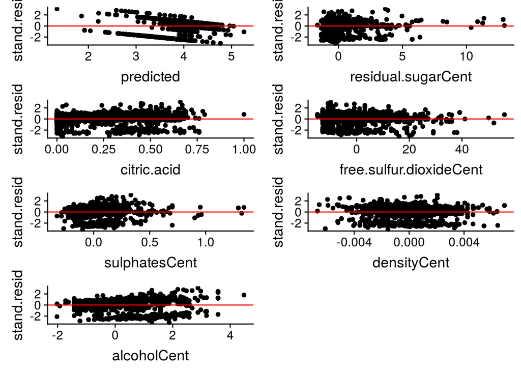

```r
# standardized residuals
p1 <- ggplot(data=data, aes(x=predicted, y=stand.resid)) + geom_point()+  geom_hline(yintercept=0, color="red")
p2 <- ggplot(data=data, aes(x=residual.sugarCent, y=stand.resid)) + geom_point()+  geom_hline(yintercept=0, color="red")
p3 <- ggplot(data=data, aes(x=citric.acid, y=stand.resid)) + geom_point()+  geom_hline(yintercept=0, color="red")
p4 <- ggplot(data=data, aes(x=free.sulfur.dioxideCent, y=stand.resid)) + geom_point()+  geom_hline(yintercept=0, color="red")
p5 <- ggplot(data=data, aes(x=sulphatesCent, y=stand.resid)) + geom_point()+  geom_hline(yintercept=0, color="red")
p6 <- ggplot(data=data, aes(x=densityCent, y=stand.resid)) + geom_point()+  geom_hline(yintercept=0, color="red")
p7 <- ggplot(data=data, aes(x=alcoholCent, y=stand.resid)) + geom_point()+  geom_hline(yintercept=0, color="red")

plot_grid(p1, p2, p3, p4, p5, p6, p7, ncol=2, nrow=4)
```

The standardized residuals show some points with magnitude greater than 2, but overall, in combination with our observation from Cook’s Distance and just one data point with high leverage away from other points, we can conclude there isn’t any obvious influential points in this model.

### Multicollinearity

```r
kable(tidy(vif(final.model)))
```

| names | x |
| --- | --- |
| residual.sugarCent | 1.402748 |
| citric.acid | 1.425081 |
| free.sulfur.dioxideCent | 3.169724 |
| sulphatesCent | 3.922514 |
| densityCent | 2.274231 |
| alcoholCent | 1.825881 |
| citric.acid:free.sulfur.dioxideCent | 3.249458 |
| citric.acid:sulphatesCent | 3.832337 |
| free.sulfur.dioxideCent:alcoholCent | 1.097922 |
| sulphatesCent:alcoholCent | 1.187895 |

## Additional Work

```r
# compare model from stepwise selection with final model from backward selection
stepwise_new <- ols_step_both_aic(model1, details=TRUE)
```

```
## Stepwise Selection Method
## -------------------------
##
## Candidate Terms:
##
## 1 . residual.sugarCent
## 2 . citric.acid
## 3 . free.sulfur.dioxideCent
## 4 . sulphatesCent
## 5 . densityCent
## 6 . alcoholCent
## 7 . citric.acid:free.sulfur.dioxideCent
## 8 . citric.acid:sulphatesCent
## 9 . citric.acid:densityCent
## 10 . citric.acid:alcoholCent
## 11 . free.sulfur.dioxideCent:sulphatesCent
## 12 . free.sulfur.dioxideCent:densityCent
## 13 . free.sulfur.dioxideCent:alcoholCent
## 14 . sulphatesCent:densityCent
## 15 . sulphatesCent:alcoholCent
##
##  Step 0: AIC = 5315.392
##  quality ~ 1
##
##
##                                          Enter New Variables
## ----------------------------------------------------------------------------------------------------
## Variable                                 DF      AIC       Sum Sq       RSS       R-Sq     Adj. R-Sq
## ----------------------------------------------------------------------------------------------------
## citric.acid:alcoholCent                   1    5252.279    103.508    2490.482    0.040        0.039
## alcoholCent                               1    5258.390     93.971    2500.019    0.036        0.036
## sulphatesCent:alcoholCent                 1    5291.643     41.437    2552.553    0.016        0.015
## citric.acid                               1    5292.863     39.488    2554.502    0.015        0.015
## citric.acid:sulphatesCent                 1    5303.179     22.954    2571.036    0.009        0.008
## sulphatesCent                             1    5305.527     19.176    2574.814    0.007        0.007
## free.sulfur.dioxideCent:alcoholCent       1    5307.604     15.829    2578.161    0.006        0.005
## densityCent                               1    5311.101     10.185    2583.805    0.004        0.003
## free.sulfur.dioxideCent                   1    5312.446      8.011    2585.979    0.003        0.002
## residual.sugarCent                        1    5312.626      7.720    2586.270    0.003        0.002
## citric.acid:densityCent                   1    5313.982      5.526    2588.464    0.002        0.002
```

[output cut: 358 more lines]

```
##                                                Parameter Estimates
## ------------------------------------------------------------------------------------------------------------------
##                               model       Beta    Std. Error    Std. Beta      t        Sig      lower      upper
## ------------------------------------------------------------------------------------------------------------------
##                         (Intercept)      4.202         0.055                 76.846    0.000     4.095      4.309
##                         alcoholCent     -0.163         0.032       -0.137    -5.106    0.000    -0.226     -0.101
##                         citric.acid     -0.618         0.179       -0.094    -3.457    0.001    -0.969     -0.267
##             free.sulfur.dioxideCent      0.020         0.005        0.161     3.817    0.000     0.010      0.030
##                  residual.sugarCent     -0.042         0.024       -0.047    -1.760    0.079    -0.090      0.005
##           citric.acid:sulphatesCent     -2.382         0.491       -0.131    -4.854    0.000    -3.345     -1.419
##           sulphatesCent:alcoholCent     -1.318         0.192       -0.177    -6.850    0.000    -1.695     -0.941
## alcoholCent:free.sulfur.dioxideCent      0.010         0.003        0.086     3.434    0.001     0.004      0.016
## citric.acid:free.sulfur.dioxideCent     -0.042         0.016       -0.116    -2.686    0.007    -0.073     -0.011
##             citric.acid:densityCent    128.418        52.874        0.071     2.429    0.015    24.707    232.129
## ------------------------------------------------------------------------------------------------------------------
```

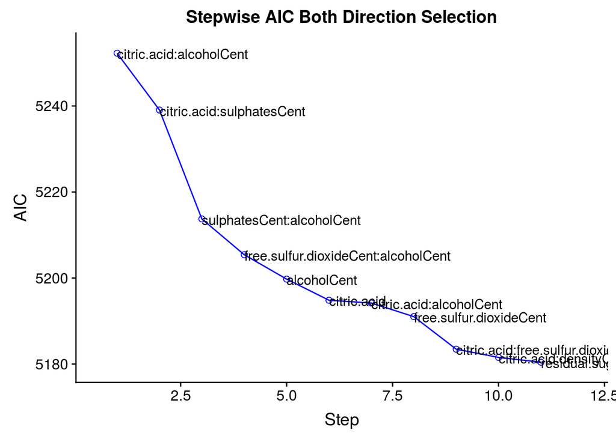

```r
# view the stepwise AIC backward elimination
plot(stepwise_new)
```

# Logistic Regression

```r
rawdata <- read.csv("./redwine_quality.csv")
data$quality <- rawdata$quality
data$quality[data$quality < 6] <- 0
data$quality[data$quality >= 6] <- 1

# Model Reduced
modellg1.null <- glm(quality ~ 1, data=data , family=binomial)

# Model Full
modellg1.full <- glm(quality ~ volatile.acidityCent  + residual.sugarCent + citric.acid + chloridesCent + free.sulfur.dioxideCent + sulphatesCent + densityCent + pHCent + alcoholCent,data=data, family = binomial)
```

```r
# forward Selection
step(modellg1.null,scope=list(upper=modellg1.full),direction="forward")
```

```
## Start:  AIC=2210.97
## quality ~ 1
##
##                           Df Deviance    AIC
## + alcoholCent              1   1865.0 1869.0
## + volatile.acidityCent     1   2033.4 2037.4
## + sulphatesCent            1   2122.8 2126.8
## + densityCent              1   2167.8 2171.8
## + citric.acid              1   2168.0 2172.0
## + chloridesCent            1   2188.6 2192.6
## + free.sulfur.dioxideCent  1   2202.9 2206.9
## <none>                         2209.0 2211.0
## + pHCent                   1   2209.0 2213.0
## + residual.sugarCent       1   2209.0 2213.0
##
## Step:  AIC=1869.03
## quality ~ alcoholCent
##
##                           Df Deviance    AIC
## + volatile.acidityCent     1   1752.5 1758.5
## + sulphatesCent            1   1804.7 1810.7
## + citric.acid              1   1841.4 1847.4
## + pHCent                   1   1846.8 1852.8
## + densityCent              1   1857.9 1863.9
## <none>                         1865.0 1869.0
## + free.sulfur.dioxideCent  1   1863.3 1869.3
## + residual.sugarCent       1   1864.2 1870.2
## + chloridesCent            1   1864.8 1870.8
##
## Step:  AIC=1758.5
## quality ~ alcoholCent + volatile.acidityCent
##
##                           Df Deviance    AIC
## + sulphatesCent            1   1724.5 1732.5
## + free.sulfur.dioxideCent  1   1749.7 1757.7
## + densityCent              1   1750.1 1758.1
## <none>                         1752.5 1758.5
## + pHCent                   1   1750.7 1758.7
## + citric.acid              1   1750.8 1758.8
## + residual.sugarCent       1   1751.8 1759.8
```

[output cut: 49 more lines]

```
##     chloridesCent + free.sulfur.dioxideCent + citric.acid + pHCent
##
##                      Df Deviance    AIC
## + densityCent         1   1698.9 1716.9
## <none>                    1701.7 1717.7
## + residual.sugarCent  1   1701.7 1719.7
##
## Step:  AIC=1716.88
## quality ~ alcoholCent + volatile.acidityCent + sulphatesCent +
##     chloridesCent + free.sulfur.dioxideCent + citric.acid + pHCent +
##     densityCent
##
##                      Df Deviance    AIC
## <none>                    1698.9 1716.9
## + residual.sugarCent  1   1698.3 1718.3
```

```
##
## Call:  glm(formula = quality ~ alcoholCent + volatile.acidityCent +
##     sulphatesCent + chloridesCent + free.sulfur.dioxideCent +
##     citric.acid + pHCent + densityCent, family = binomial, data = data)
##
## Coefficients:
##             (Intercept)              alcoholCent     volatile.acidityCent
##                 0.71114                  1.05568                 -3.80216
##           sulphatesCent            chloridesCent  free.sulfur.dioxideCent
##                 2.60505                 -3.79466                 -0.01193
##             citric.acid                   pHCent              densityCent
##                -1.68434                 -0.95434                 75.68124
##
## Degrees of Freedom: 1598 Total (i.e. Null);  1590 Residual
## Null Deviance:       2209
## Residual Deviance: 1699  AIC: 1717
```

```r
modellg1.selected <- glm(quality ~ alcoholCent  + volatile.acidityCent + sulphatesCent + chloridesCent + free.sulfur.dioxideCent + citric.acid + pHCent + densityCent,data=data, family = binomial)
summary(modellg1.selected)
```

```
##
## Call:
## glm(formula = quality ~ alcoholCent + volatile.acidityCent +
##     sulphatesCent + chloridesCent + free.sulfur.dioxideCent +
##     citric.acid + pHCent + densityCent, family = binomial, data = data)
##
## Deviance Residuals:
##     Min       1Q   Median       3Q      Max
## -3.3861  -0.8677   0.3184   0.8572   2.4028
##
## Coefficients:
##                          Estimate Std. Error z value Pr(>|z|)
## (Intercept)              0.711145   0.148087   4.802 1.57e-06 ***
## alcoholCent              1.055683   0.084814  12.447  < 2e-16 ***
## volatile.acidityCent    -3.802157   0.482445  -7.881 3.25e-15 ***
## sulphatesCent            2.605051   0.454235   5.735 9.75e-09 ***
## chloridesCent           -3.794657   1.516658  -2.502 0.012350 *
## free.sulfur.dioxideCent -0.011926   0.005849  -2.039 0.041462 *
## citric.acid             -1.684338   0.509051  -3.309 0.000937 ***
## pHCent                  -0.954338   0.488481  -1.954 0.050739 .
## densityCent             75.681238  45.291656   1.671 0.094727 .
## ---
## Signif. codes:  0 '***' 0.001 '**' 0.01 '*' 0.05 '.' 0.1 ' ' 1
##
## (Dispersion parameter for binomial family taken to be 1)
##
##     Null deviance: 2209.0  on 1598  degrees of freedom
## Residual deviance: 1698.9  on 1590  degrees of freedom
## AIC: 1716.9
##
## Number of Fisher Scoring iterations: 4
```

```r
kable(tidy(modellg1.selected))
```

| term | estimate | std.error | statistic | p.value |
| --- | --- | --- | --- | --- |
| (Intercept) | 0.7111446 | 0.1480871 | 4.802204 | 0.0000016 |
| alcoholCent | 1.0556830 | 0.0848137 | 12.447077 | 0.0000000 |
| volatile.acidityCent | -3.8021566 | 0.4824455 | -7.881008 | 0.0000000 |
| sulphatesCent | 2.6050510 | 0.4542355 | 5.735023 | 0.0000000 |
| chloridesCent | -3.7946575 | 1.5166583 | -2.501986 | 0.0123499 |
| free.sulfur.dioxideCent | -0.0119260 | 0.0058493 | -2.038875 | 0.0414625 |
| citric.acid | -1.6843382 | 0.5090512 | -3.308780 | 0.0009370 |
| pHCent | -0.9543379 | 0.4884814 | -1.953683 | 0.0507387 |
| densityCent | 75.6812385 | 45.2916564 | 1.670975 | 0.0947266 |

```r
modellg1.final <- glm(quality ~ alcoholCent  + volatile.acidityCent + sulphatesCent + chloridesCent + free.sulfur.dioxideCent + citric.acid,data=data, family = binomial)
summary(modellg1.final)
```

```
##
## Call:
## glm(formula = quality ~ alcoholCent + volatile.acidityCent +
##     sulphatesCent + chloridesCent + free.sulfur.dioxideCent +
##     citric.acid, family = binomial, data = data)
##
## Deviance Residuals:
##     Min       1Q   Median       3Q      Max
## -3.2135  -0.8735   0.3138   0.8834   2.3526
##
## Coefficients:
##                          Estimate Std. Error z value Pr(>|z|)
## (Intercept)              0.495163   0.120787   4.099 4.14e-05 ***
## alcoholCent              0.951016   0.070958  13.402  < 2e-16 ***
## volatile.acidityCent    -3.548641   0.451559  -7.859 3.88e-15 ***
## sulphatesCent            2.703043   0.446393   6.055 1.40e-09 ***
## chloridesCent           -3.770068   1.466806  -2.570   0.0102 *
## free.sulfur.dioxideCent -0.013254   0.005858  -2.262   0.0237 *
## citric.acid             -0.875529   0.391892  -2.234   0.0255 *
## ---
## Signif. codes:  0 '***' 0.001 '**' 0.01 '*' 0.05 '.' 0.1 ' ' 1
##
## (Dispersion parameter for binomial family taken to be 1)
##
##     Null deviance: 2209.0  on 1598  degrees of freedom
## Residual deviance: 1705.7  on 1592  degrees of freedom
## AIC: 1719.7
##
## Number of Fisher Scoring iterations: 4
```

```r
kable(tidy(modellg1.final))
```

| term | estimate | std.error | statistic | p.value |
| --- | --- | --- | --- | --- |
| (Intercept) | 0.4951634 | 0.1207867 | 4.099486 | 0.0000414 |
| alcoholCent | 0.9510158 | 0.0709582 | 13.402476 | 0.0000000 |
| volatile.acidityCent | -3.5486411 | 0.4515594 | -7.858636 | 0.0000000 |
| sulphatesCent | 2.7030432 | 0.4463930 | 6.055299 | 0.0000000 |
| chloridesCent | -3.7700684 | 1.4668058 | -2.570257 | 0.0101623 |
| free.sulfur.dioxideCent | -0.0132536 | 0.0058580 | -2.262476 | 0.0236680 |
| citric.acid | -0.8755285 | 0.3918921 | -2.234106 | 0.0254761 |

```r
kable(tidy(vif(modellg1.final)))
```

| names | x |
| --- | --- |
| alcoholCent | 1.050002 |
| volatile.acidityCent | 1.542159 |
| sulphatesCent | 1.416972 |
| chloridesCent | 1.433665 |
| free.sulfur.dioxideCent | 1.018900 |
| citric.acid | 1.650265 |

```r
data$pred <- predict.glm(modellg1.final)
data$res <- residuals.glm(modellg1.final)
```

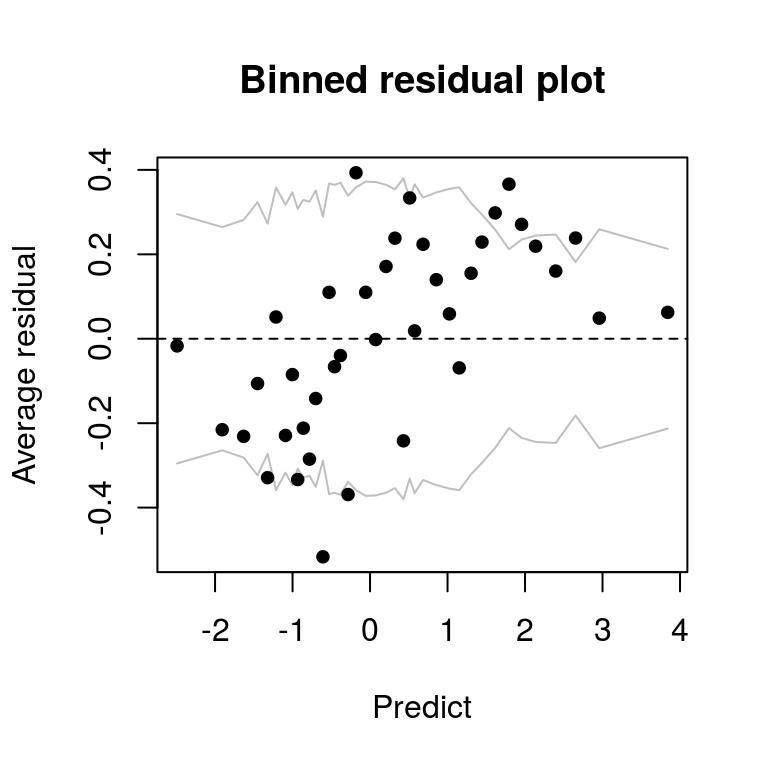

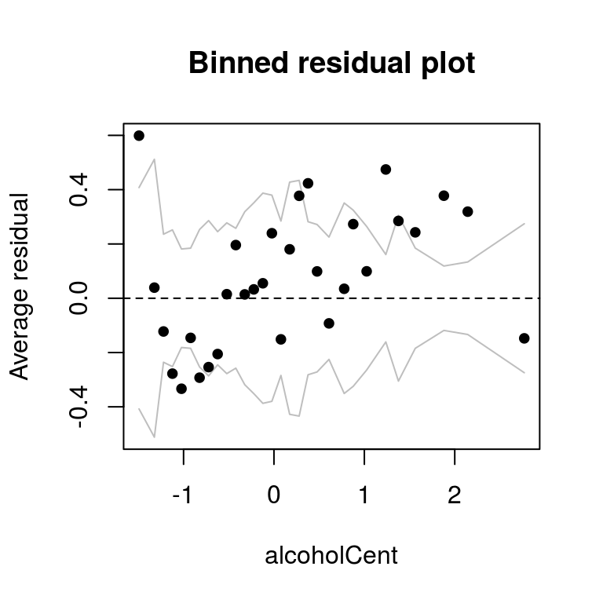

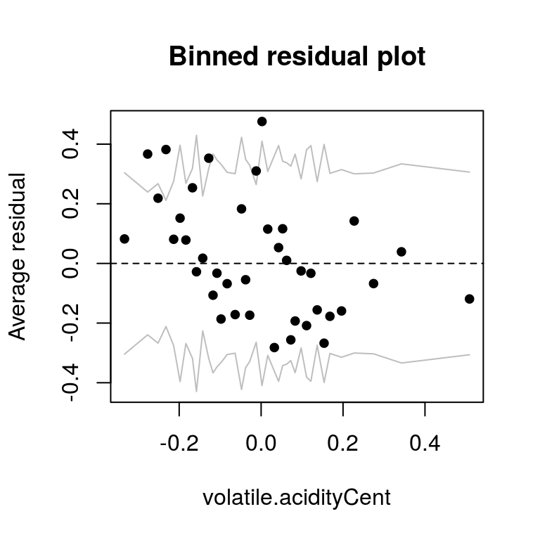

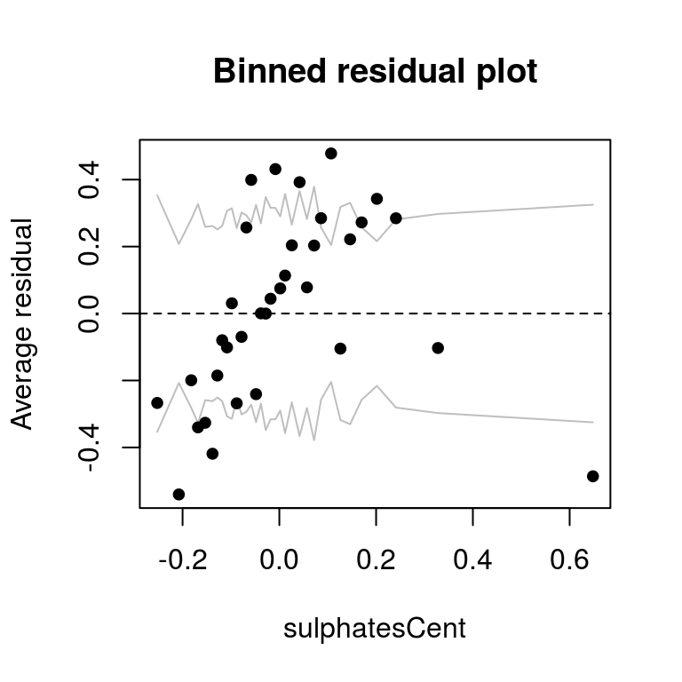

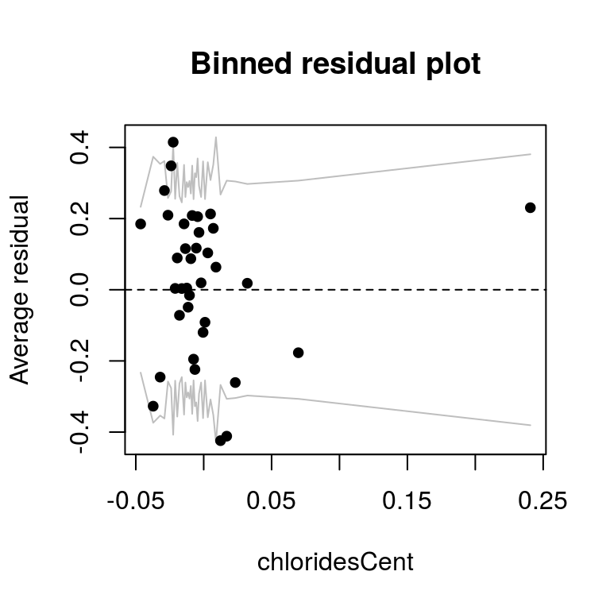

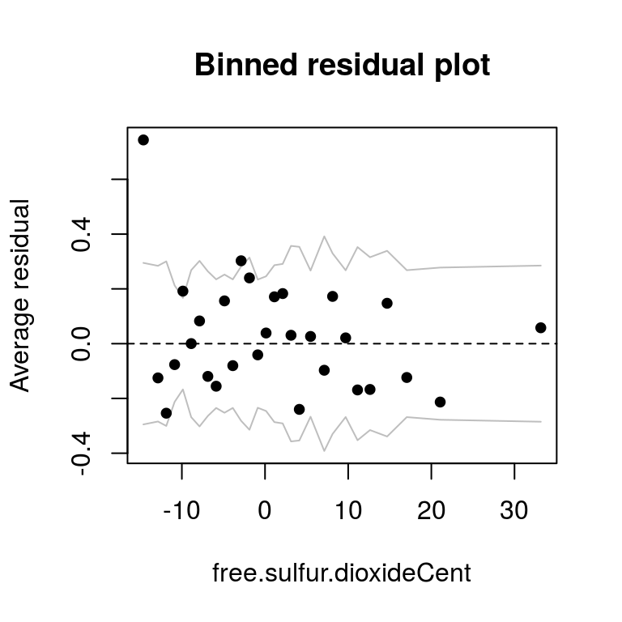

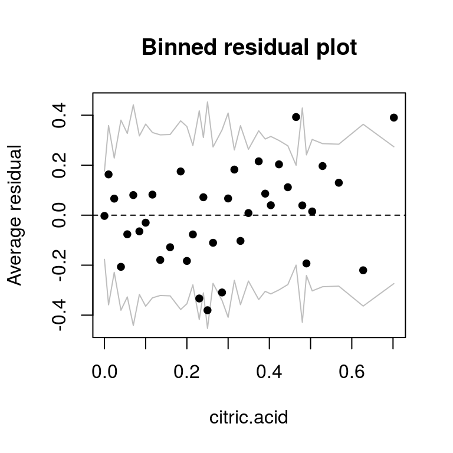

sulfates cent need transformation volatile.acidityCent also needs tranformation alcoholCent also needs transformation

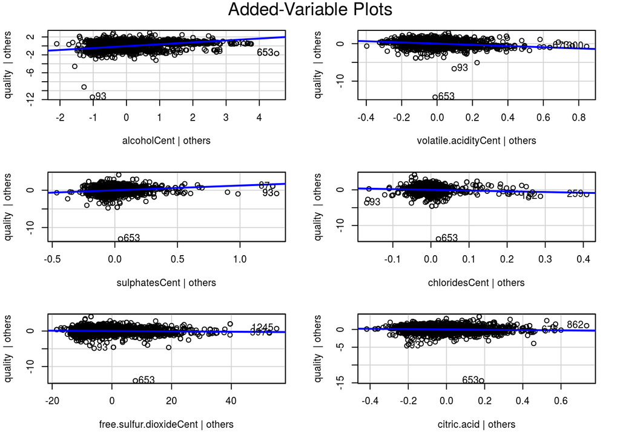

```r
avPlots(modellg1.final)
```

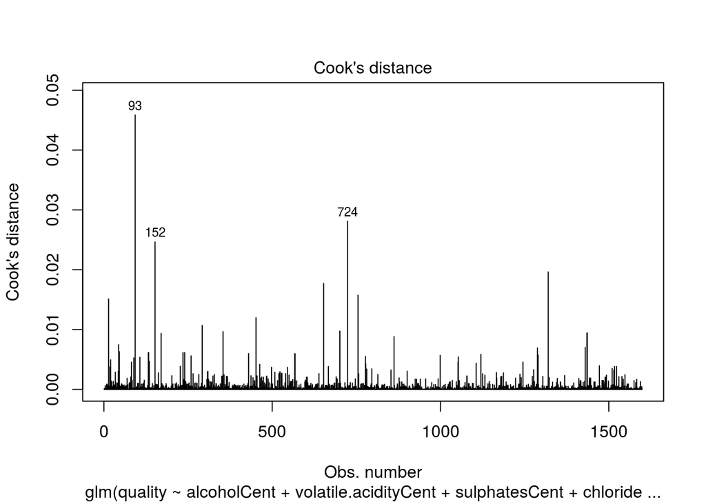

```r
cutoff <- cooks.distance(modellg1.final)
plot(modellg1.final, which=4, cook.levels=cutoff)
```

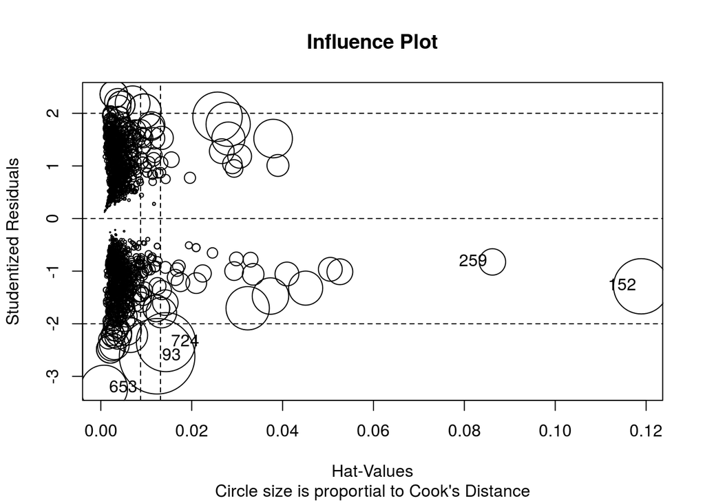

```
##        StudRes          Hat       CookD
## 93  -2.6180001 0.0123886268 0.045853660
## 152 -1.2882242 0.1189215890 0.024622603
## 259 -0.8246309 0.0861821330 0.005602629
## 653 -3.2327072 0.0007125379 0.017709691
## 724 -2.3495059 0.0143290897 0.028108832
```

```r
influencePlot(modellg1.final,    main="Influence Plot", sub="Circle size is proportial to Cook's Distance" )
```

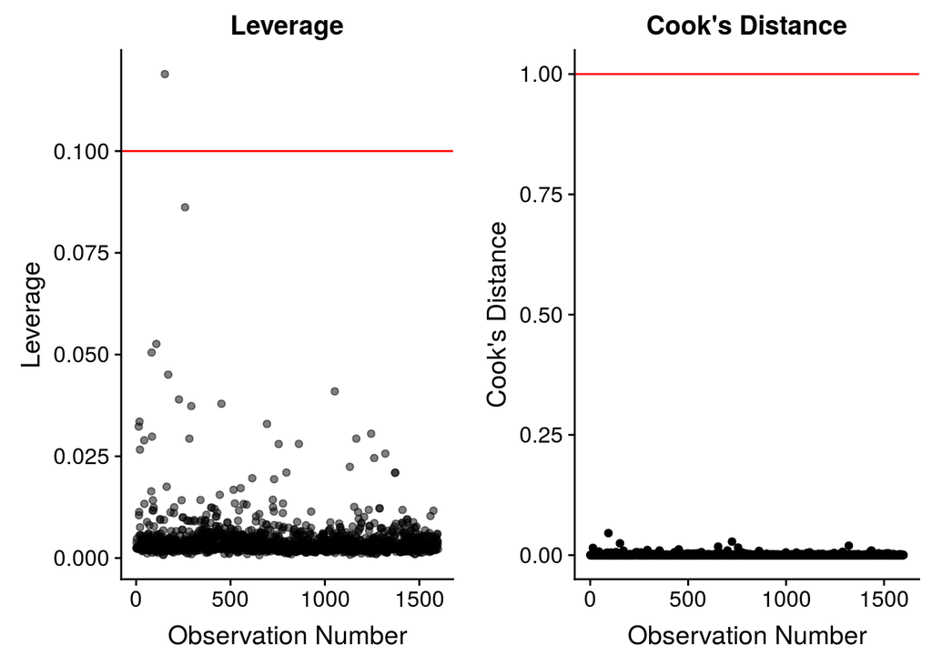

```r
data <- data %>%
  mutate(leverage = hatvalues(modellg1.final),
         cooks = cooks.distance(modellg1.final),
         stand.resid = rstandard(modellg1.final),
         obs.num = row_number())
p3 <- ggplot(data=data, aes(x=obs.num,y=leverage)) +
  geom_point(alpha=0.5) +
  geom_hline(yintercept=0.1,color="red")+
  labs(x="Observation Number",y="Leverage",title="Leverage")

p4 <- ggplot(data=data, aes(x=obs.num,y=cooks)) +
  geom_point() +
  geom_hline(yintercept=1,color="red")+
  labs(x="Observation Number",y="Cook's Distance",title="Cook's Distance")

plot_grid(p3,p4,ncol = 2)
```